# All Morphology: Wing Time Series

Anastasia Bernat

4/1/2021

## Introduction

If you have continuous target variable, then it is a regression problem. For instance, in flight trials we have the flight distance to predict, which is continuous. Hence this becomes a regression problem. About time series, when the datapoints are time dependent, then it becomes a time series problem. Each data point has an order and is, typically, related to the data points before and after by some underlying process.

In turn, a times series regression is a statistical method for predicting a future response based on the response history (known as autoregressive dynamics) and the transfer of dynamics from relevant predictors. Time series regression is commonly used for modeling and forecasting of economic, financial, and biological systems.

There are three concepts then to keep in mind:

- **Stationary**: if any trends or patterns in the time series are independent with time. (A linear regression equivalent to a time series at stationarity). There is strong and weak stationary.
- **Non-Stationary**: trends dependent in time in the mean or statistical deviation of the data points.
- **Autocorrelation**: “memory”; the degree to which time series values in period(t) are related to time series values in periods (t+1, t+2, t+3…). For this, we can test to see how long certain values last in a system.

There are also three words and their definitions to remember:

- **variance** = amplitude of the data points
- **mean** = the central value of the data points
- **covariance** = frequency of the data points

Questions about time series often asked include,

- Is there any trend, seasonality, or any outliers?
- Is there a long-run cycle or period unrelated to seasonality factors?
- Is there a constant variance over time?
- Are there any abrupt changes to either the level of the series or the variance?

So how can you answer these questions through a time series regression and code? And where do you begin to test stationarity or visualize autocorrelation? And finally, how do you handle non-stationarity?

## Cleaning Data and Sourcing Scripts

```r
source_path = "~/Desktop/git_repositories/SBB-dispersal/avbernat_working_on/Rsrc/"

script_names = c("compare_models.R","regression_output.R", "clean_morph_data.R",
                 "AICprobabilities.R")

for (script in script_names) {
  path = paste0(source_path, script)
  source(path)
}
```

### Read the data

```r
data_list <- read_morph_data("data/allmorphology9.21.20.csv")
raw_data = data_list[[1]]
data_long = data_list[[2]]

# Datetime
raw_data$date <- paste(raw_data$month, raw_data$year, sep="/")
raw_data$datetime <- as.yearmon(raw_data$date, "%B/%Y")
raw_data$datetime <- as.factor(raw_data$datetime)
n_missing_dates = nrow(raw_data[is.na(raw_data$datetime),])
cat("number of missing dates:", n_missing_dates)
```

```
## number of missing dates: 320
```

```r
# merge May 2015 with April 2015 because very few bugs were collected in May 2015.
raw_data$date[raw_data$date == "May/2015"] = "April/2015"

raw_data$datetime <- as.yearmon(raw_data$date, "%B/%Y")
raw_data$datetime <- as.factor(raw_data$datetime)
raw_data
```

```
##         pophost      population sex beak thorax  wing  body     month   year
## 24    K.elegans        Ft.Myers   M 5.24   2.86  7.98 10.92     April 2013.0
## 25    K.elegans        Ft.Myers   M 5.72   3.09  8.27 11.58     April 2013.0
## 26    K.elegans        Ft.Myers   M 5.81   3.10  8.72 11.54     April 2013.0
## 27    K.elegans        Ft.Myers   M 4.60   2.51  6.57  8.95     April 2013.0
## 28    K.elegans        Ft.Myers   M 5.75   2.97  8.38 11.38     April 2013.0
## 29    K.elegans        Ft.Myers   M 5.42   2.96  7.85  10.8     April 2013.0
## 30    K.elegans        Ft.Myers   M 5.64   2.87  8.02 10.67     April 2013.0
## 31    K.elegans        Ft.Myers   M 5.22   2.60  7.36 10.14     April 2013.0
## 32    K.elegans        Ft.Myers   M 5.17   2.87  7.81 10.42     April 2013.0
## 33    K.elegans        Ft.Myers   F 6.99   3.78  9.93  13.5     April 2013.0
## 34    K.elegans        Ft.Myers   F 7.38   3.35  9.07 12.45     April 2013.0
## 35    K.elegans        Ft.Myers   M 5.09   2.81  7.77 10.45     April 2013.0
## 36    K.elegans        Ft.Myers   M 5.55   3.19  8.57 11.57     April 2013.0
## 37    K.elegans        Ft.Myers   M 5.81   3.33  8.51 11.58     April 2013.0
```

[output cut: 16215 more lines]

## Manipulating Time Series Data

Need to split by sex and host plant.

### Wing Length

Using xts & zoo R Libraries.

https://rstudio-pubs-static.s3.amazonaws.com/288218_117e183e74964557a5da4fc5902fc671.html

```r
# remove NA dates
d = raw_data %>%
  filter(!is.na(wing), !is.na(datetime))

# get wing length averages using vectorization
wing_avg = tapply(X=d$wing, INDEX=d$datetime, FUN=mean, na.rm=T)
monyear = unique(d$datetime)

# generate datetime object | datetime object needs a date, which I initialized at 01 for each month
monyeardate <- paste(monyear," 01",sep="")
date = as.Date(monyeardate, "%b %Y %d")
```

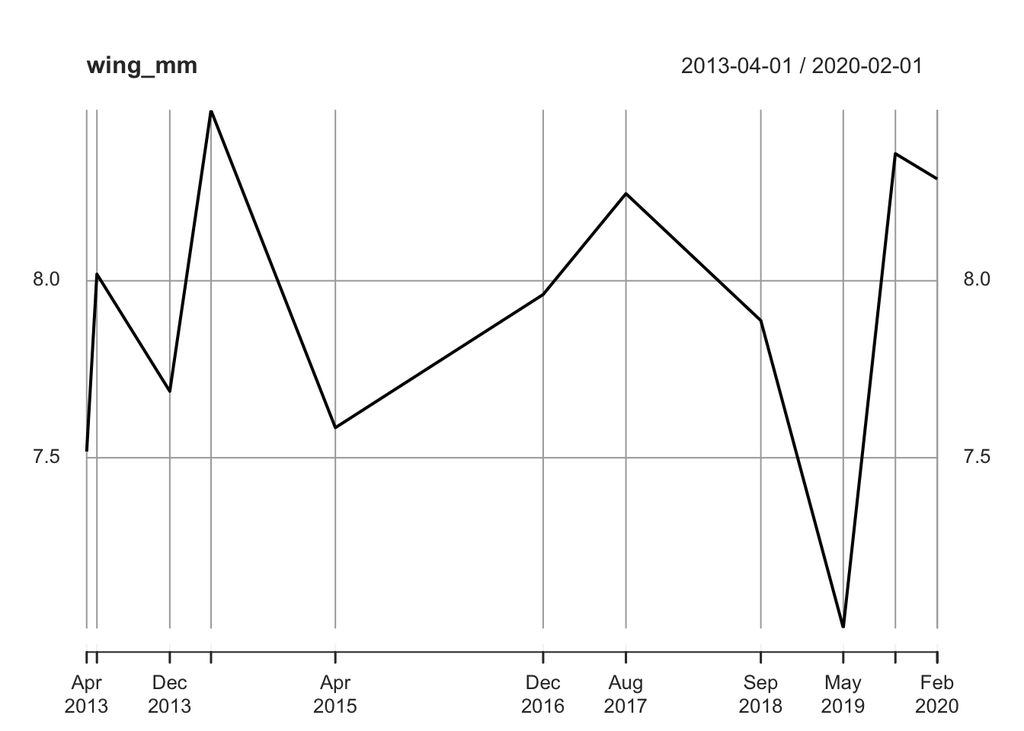

```r
wing_mm = xts(wing_avg, date)
colnames(wing_mm) <- "wing"
plot(wing_mm)
```

```r
adf.test(wing_mm$wing) # this is stationary
```

```
##
##  Augmented Dickey-Fuller Test
##
## data:  wing_mm$wing
## Dickey-Fuller = -4.3673, Lag order = 2, p-value = 0.01044
## alternative hypothesis: stationary
```

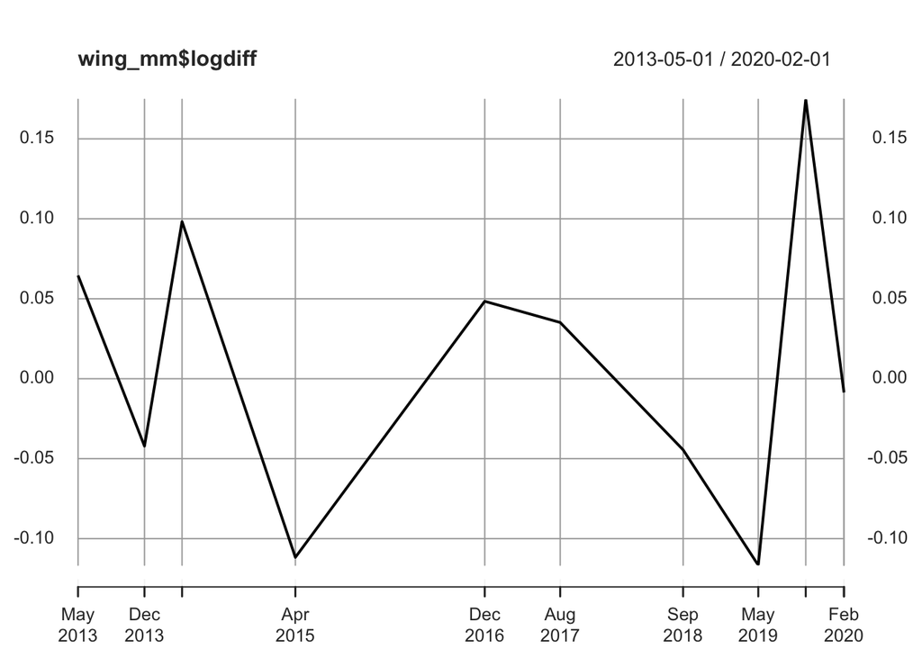

```r
wing_mm$logdiff <- diff(log(wing_mm$wing)) # <--- Make sure you understand what's happening here!
wing_mm <- wing_mm[-1,]
plot(wing_mm$logdiff)
```

```r
adf.test(wing_mm$logdiff) # this is stationary
```

```
##
##  Augmented Dickey-Fuller Test
##
## data:  wing_mm$logdiff
## Dickey-Fuller = -11.809, Lag order = 2, p-value = 0.01
## alternative hypothesis: stationary
```

Stationarity can be defined in precise mathematical terms, but for our purpose we mean a flat looking series, without trend, constant variance over time, a constant autocorrelation structure over time and no periodic fluctuations (seasonality). So the low p value means we do have stationarity.

lag order = shift every 2 years detected?

Use an ACF and a PCF plot to identify temporal dependence in the wing_mm$logdiff data.

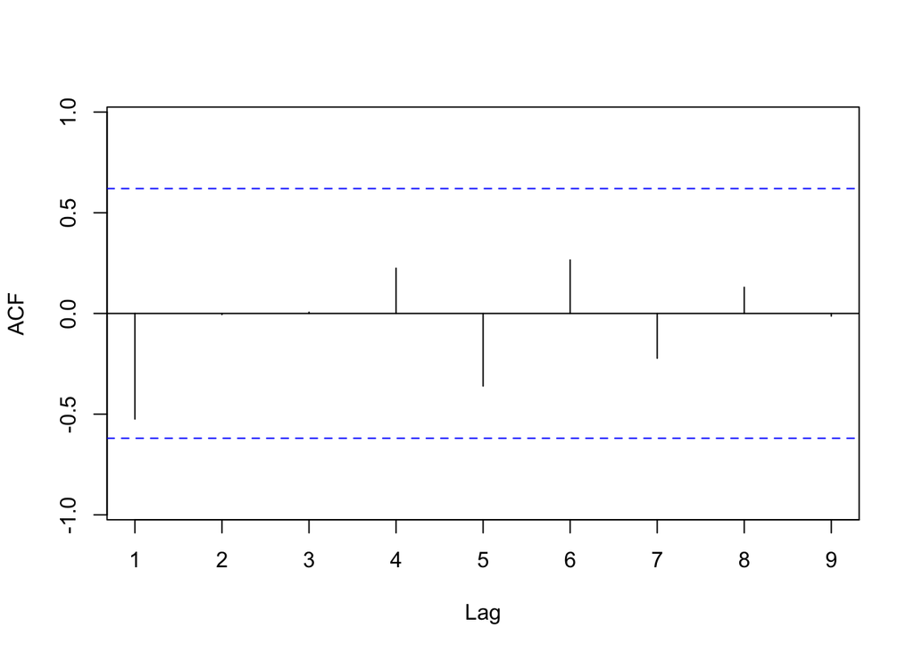

```r
# Make an ACF plot
Acf(wing_mm$logdiff, main='')
```

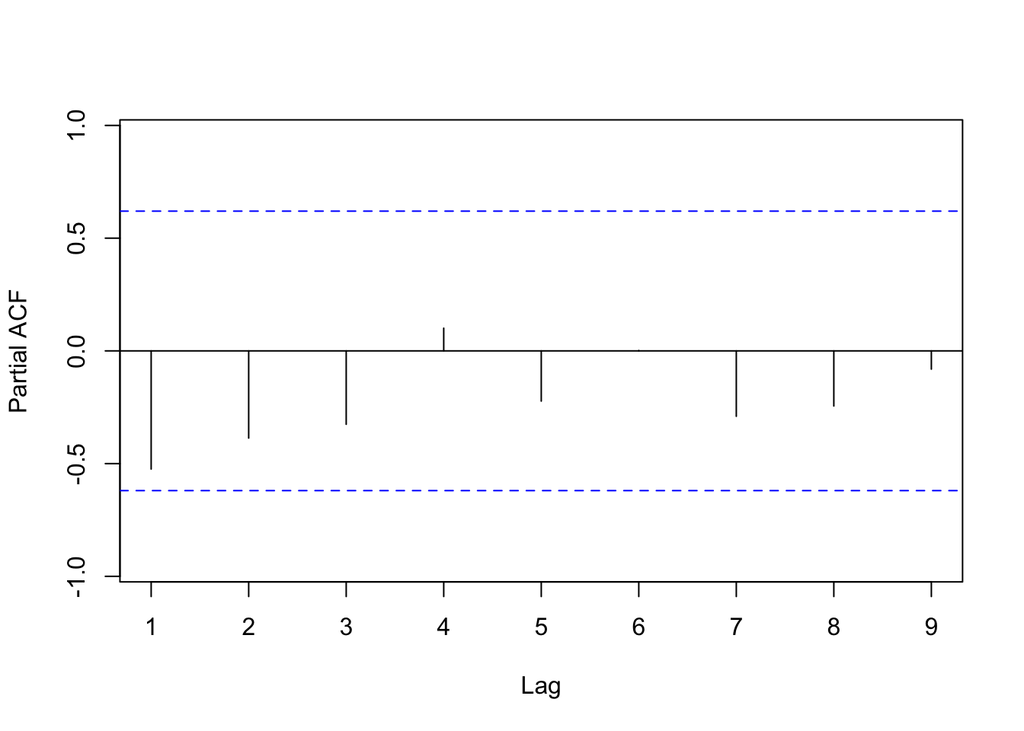

```r
# Make a PACF plot
Acf(wing_mm$logdif, type="partial", main='')
```

### Wing2body

```r
data_long<-raw_data[raw_data$w_morph=="L",]

###remove individuals with torn wings first.
data_long$drop <- FALSE

for(row in 1:nrow(data_long)){
    if(length(unlist(strsplit(strsplit(paste("test ", data_long$notes[row], " test", sep=""), "torn")[[1]], "wing")))>2){
         #browser()
         data_long$drop[row] <- TRUE
         }
}

data_long <- data_long[data_long$drop==FALSE,]

data_long$wing2body <- data_long$wing/as.numeric(data_long$body)
```

```r
# remove NA dates
d = data_long %>%
  filter(!is.na(wing2body), !is.na(datetime))

# get wing length averages using vectorization
ratio_avg = tapply(X=d$wing2body, INDEX=d$datetime, FUN=mean, na.rm=T)
ratio_avg = ratio_avg[!is.na(ratio_avg)]
monyear = unique(d$datetime)

# generate datetime object | datetime object needs a date, which I initialized at 01 for each month
monyeardate <- paste(monyear," 01",sep="")
date = as.Date(monyeardate, "%b %Y %d")
```

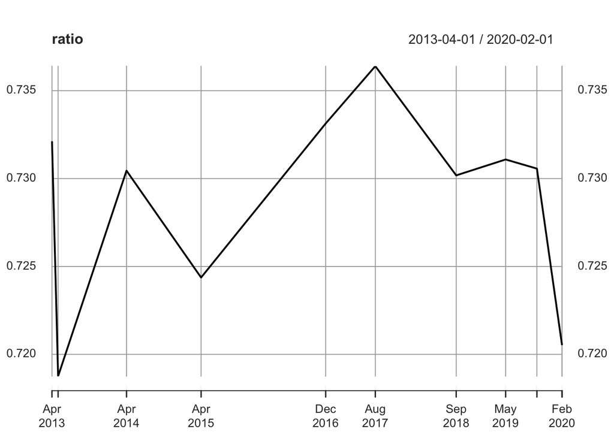

```r
ratio = xts(ratio_avg, date)
colnames(ratio) <- "wing2body"

plot(ratio)
```

```r
adf.test(ratio$wing2body) # this is not stationarity
```

```
##
##  Augmented Dickey-Fuller Test
##
## data:  ratio$wing2body
## Dickey-Fuller = 0.043051, Lag order = 2, p-value = 0.99
## alternative hypothesis: stationary
```

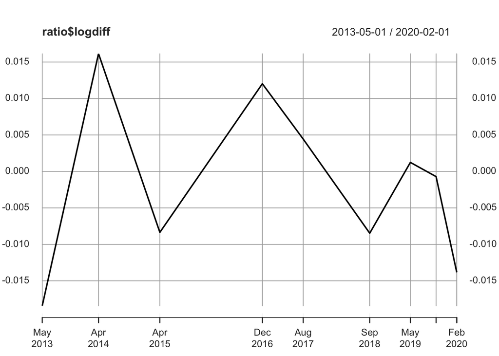

```r
ratio$logdiff <- diff(log(ratio$wing)) # <--- Make sure you understand what's happening here!
ratio <- ratio[-1,]
plot(ratio$logdiff)
```

```r
adf.test(ratio$logdiff) # this is stationary
```

```
##
##  Augmented Dickey-Fuller Test
##
## data:  ratio$logdiff
## Dickey-Fuller = -9.6113, Lag order = 2, p-value = 0.01
## alternative hypothesis: stationary
```